# Orientation Tuning Notebook

# Summary

An orientation tuning model building on a `Biol Cybern (2012) 106:177–189`. This is a model of V1 simple cells receiving input from on and off center LGN cells.

# Random seed for the simulation

```r
set.seed(7983412)
```

# LGN cells

LGN on and off center-surround cells are modeled as a difference of 2D Gaussians where the standard deviation of the second (inner) Gaussian is half that of the first.

```r
DoG_center_on = function(x, y, sigma) {
  Gauss_1 = 1/(2*pi*sigma^2)*exp(-(x^2+y^2)/(2*sigma^2))
  Gauss_2 = 1/(2*pi*(.5*sigma)^2)*exp(-(x^2+y^2)/(2*(.5*sigma)^2))
  -1*(Gauss_1 - Gauss_2)
}
DoG_center_off = function(x, y, sigma) {
  -1*DoG_center_on(x, y, sigma)
}
LGN_cell_response = function(x, y, polarity, sigma) {
  response = NULL
  if (polarity == "on") response = DoG_center_on(x, y, sigma)
  if (polarity == "off") response = DoG_center_off(x, y, sigma)
  response
}
```

Example on and off center filters are shown below.

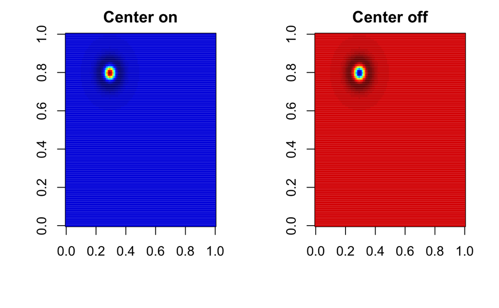

```r
x = 1:100
y = x
center_x = 30
center_y = 80
on_center_example = outer(x-center_x, y-center_y, LGN_cell_response, polarity="on", sigma=5) # adjusted sig
off_center_example = outer(x-center_x, y-center_y, LGN_cell_response, polarity="off", sigma=5) # adjusted sig
par(mfrow=c(1,2))
image(on_center_example, main="Center on", col=jet.col())
image(off_center_example, main="Center off",  col=jet.col())
```

# The LGN population

In this model, the LGN will contain ~50% on and ~50% off center cells.

```r
n_LGN_cells = 20000
LGN_cell_parameters =
  data.frame(
    center_x = sample(1:100, n_LGN_cells, replace=T),
    center_y = sample(1:100, n_LGN_cells, replace=T),
    polarity = sample(c("on", "off"), n_LGN_cells, replace=T),
    cell_id = seq_len(n_LGN_cells)
  )
w_photoreceptors_to_LGN = sapply(seq_len(n_LGN_cells), function(i) {
  x = 1:100
  y = x
  center_x = LGN_cell_parameters$center_x[i]
  center_y = LGN_cell_parameters$center_y[i]
  polarity = LGN_cell_parameters$polarity[i]
  outer(x-center_x, y-center_y, LGN_cell_response, polarity=polarity, sigma=3) # adjusted sig
})
```

# LGN responses

LGN cells will be rectified units.

```r
response_LGN = function(images, w_photoreceptors_to_LGN) {
  y_LGN = np$dot(images, w_photoreceptors_to_LGN)
  y_LGN[y_LGN < 0] = 0
  y_LGN
}
```

# V1 cells

V1 cells will linear units summing inputs from LGN cells. First I will specify a pool of possible synaptic weights. This approximately a truncated log-normal distribution, as described for hippocampal granule cells. A more realistic set of weights for V1 may be used in a later iteration of the model.

```r
P = function(s) {
  A = 100.7
  B = 0.02
  sigma1 = 0.022
  sigma2 = 0.018
  sigma3 = 0.150
  A*(1-exp(-s/sigma1))*(exp(-s/sigma2)+B*exp(-s/sigma3))
}
W = function(s) {
  (s/.2)*(s/(s+0.0314))
}
s = runif(1000000, 0, .2)
p = runif(1000000, 0, 23)
synaptic_size_pool = s[p<=P(s)]
synaptic_strength_pool = W(synaptic_size_pool)
```

```r
n_V1_cells = 1000
V1_cell_parameters =
  data.frame(
    center_x = sample(31:70, n_V1_cells, replace=T),
    center_y = sample(31:70, n_V1_cells, replace=T),
    prefered_orientation = runif(n_V1_cells, -pi/2, pi/2)
  )
w_LGN_to_V1 =
  sapply(seq_len(n_V1_cells), function(i) {
    center_x = V1_cell_parameters$center_x[i]
    center_y = V1_cell_parameters$center_y[i]
    prefered_orientation = V1_cell_parameters$prefered_orientation[i]

    # center-on inputs
    bar_coordinate_matrix = cbind(seq(-20, 20, length=100), rep(-15, 100)) %>%
      spdep::Rotation(prefered_orientation)
    bar_coordinate_matrix[,1] %<>% {. + center_x}
    bar_coordinate_matrix[,2] %<>% {. + center_y}
    LGN_on_cell_parameters =
      LGN_cell_parameters %>%
      filter(polarity == "on")
    distances_x =
      outer(
        X=bar_coordinate_matrix[,1],
        Y=LGN_on_cell_parameters$center_x,
        FUN=function(a, b) {(a-b)^2}
        )
    distances_y =
      outer(
        X=bar_coordinate_matrix[,2],
        Y=LGN_on_cell_parameters$center_y,
        FUN=function(a, b) {(a-b)^2}
        )
    distances = distances_x + distances_y

    minimal_distance_idx =
      distances %>%
      rank() %>%
      matrix(nrow(distances), ncol(distances)) %>%
      melt() %>%
      rename(Bar_position=Var1, LGN_cell=Var2, Rank=value) %>%
      arrange(Rank) %>%
      mutate(LGN_duplicate = duplicated(LGN_cell)) %>%
      filter(LGN_duplicate == F) %$%
      LGN_cell[1:33]

    LGN_input_ids = LGN_on_cell_parameters$cell_id[minimal_distance_idx]
    w = rep(0, n_LGN_cells) %>% {.[LGN_input_ids]=sample(synaptic_strength_pool, length(LGN_input_ids));.}

    # center-off inputs
    bar_coordinate_matrix =
      cbind(
        seq(-30, 30, length=100),
        rep(0, 100)
        ) %>%
      spdep::Rotation(prefered_orientation)
    bar_coordinate_matrix[,1] %<>% {. + center_x}
    bar_coordinate_matrix[,2] %<>% {. + center_y}
    LGN_off_cell_parameters =
      LGN_cell_parameters %>%
      filter(polarity == "off")
    distances_x =
      outer(
        X=bar_coordinate_matrix[,1],
        Y=LGN_off_cell_parameters$center_x,
        FUN=function(a, b) {(a-b)^2}
        )
    distances_y =
      outer(
        X=bar_coordinate_matrix[,2],
        Y=LGN_off_cell_parameters$center_y,
        FUN=function(a, b) {(a-b)^2}
        )
    distances = distances_x + distances_y

    minimal_distance_idx =
      distances %>%
      rank() %>%
      matrix(nrow(distances), ncol(distances)) %>%
      melt() %>%
      rename(Bar_position=Var1, LGN_cell=Var2, Rank=value) %>%
      arrange(Rank) %>%
      mutate(LGN_duplicate = duplicated(LGN_cell)) %>%
      filter(LGN_duplicate == F) %$%
      LGN_cell[1:64]

    LGN_input_ids = LGN_off_cell_parameters$cell_id[minimal_distance_idx]
    w[LGN_input_ids] = sample(synaptic_strength_pool, length(LGN_input_ids))

    # center-on inputs
    bar_coordinate_matrix =
      cbind(
        seq(-20, 20, length=100),
        rep(15, 100)
        ) %>%
      spdep::Rotation(prefered_orientation)
    bar_coordinate_matrix[,1] %<>% {. + center_x}
    bar_coordinate_matrix[,2] %<>% {. + center_y}
    LGN_on_cell_parameters =
      LGN_cell_parameters %>%
      filter(polarity == "on")
    distances_x =
      outer(
        X=bar_coordinate_matrix[,1],
        Y=LGN_on_cell_parameters$center_x,
        FUN=function(a, b) {(a-b)^2}
        )
    distances_y =
      outer(
        X=bar_coordinate_matrix[,2],
        Y=LGN_on_cell_parameters$center_y,
        FUN=function(a, b) {(a-b)^2}
        )
    distances = distances_x + distances_y

    minimal_distance_idx =
      distances %>%
      rank() %>%
      matrix(nrow(distances), ncol(distances)) %>%
      melt() %>%
      rename(Bar_position=Var1, LGN_cell=Var2, Rank=value) %>%
      arrange(Rank) %>%
      mutate(LGN_duplicate = duplicated(LGN_cell)) %>%
      filter(LGN_duplicate == F) %$%
      LGN_cell[1:33]

    LGN_input_ids = LGN_on_cell_parameters$cell_id[minimal_distance_idx]
    w[LGN_input_ids] = sample(synaptic_strength_pool, length(LGN_input_ids))

    w
  })
```

# Stimuli

The stimuli will be 2D gratings at various orientations.

```r
x = seq(-1, 1, length=100)
y = seq(-1, 1, length=100)
I = function(x, y, theta, phi) {
  1 + sin(10*(x*cos(theta) - y*sin(theta)) - phi)
}
all_theta = c()
stimuli = sapply(seq(-pi/2, pi/2, .1), function(theta) {
  phi = seq(0, 2*pi-.1, .1)
  all_theta <<- c(all_theta, rep(theta, length(phi)))
  sapply(1:length(phi), function(i) {
    stimulus = outer(X=x, Y=y, FUN=I, theta=theta, phi=phi[i])
    c(stimulus)
  }) %>%
    t()
}, simplify=F) %>%
  do.call(rbind, .)
```

Examples of stimulus gratings are shown below.

```r
par(mfrow=c(1,3))
stimuli[1,] %>% matrix(100, 100) %>% image(col=jet.col(), main=round(all_theta[50]))
stimuli[100,] %>% matrix(100, 100) %>% image(col=jet.col(), main=round(all_theta[100]))
```

[figure not shown]

```r
stimuli[200,] %>% matrix(100, 100) %>% image(col=jet.col(), main=round(all_theta[200]))
```

# Synapse turnover

```r
# turnover = function(w_LGN_to_V1, frac_turnover=.1) {
#   apply(w_LGN_to_V1, 2, function(w_LGN_to_V1_i) {
#     realized_synapses = which(w_LGN_to_V1_i > 0)
#     unrealized_synapses = which(w_LGN_to_V1_i == 0)
#     n_turnover = realized_synapses %>% length() %>% round() %>% {frac_turnover*.}
#     w_LGN_to_V1_i[sample(realized_synapses, n_turnover)] = 0
#     w_LGN_to_V1_i[sample(unrealized_synapses, n_turnover)] = sample(synaptic_strength_pool, n_turnover)
#     w_LGN_to_V1_i
#   })
# }
Gauss = function(x, y, sigma) 1/(2*pi*sigma^2)*exp(-(x^2+y^2)/(2*sigma^2))
turnover = function(w_LGN_to_V1, frac_turnover=.1) {
  sapply(1:nrow(V1_cell_parameters), function(i) {
    V1_center_x = V1_cell_parameters$center_x[i]
    V1_center_y = V1_cell_parameters$center_y[i]

    w_LGN_to_V1_i = w_LGN_to_V1[,i]
    realized_synapses = which(w_LGN_to_V1_i > 0)
    unrealized_synapses = which(w_LGN_to_V1_i == 0)

    n_turnover = realized_synapses %>% length() %>% {frac_turnover*.} %>% round()
    w_LGN_to_V1_i[sample(realized_synapses, n_turnover)] = 0

    LGN_center_x = LGN_cell_parameters$center_x[unrealized_synapses]
    LGN_center_y = LGN_cell_parameters$center_y[unrealized_synapses]

    g = mapply(Gauss, LGN_center_x - V1_center_x, LGN_center_y - V1_center_y, sigma=10)
    new_synapses = rbinom(length(unrealized_synapses), 1, (n_turnover*g/sum(g))) ####
    new_synapses = which(new_synapses == 1)
    new_synapses = unrealized_synapses[new_synapses]
    w_LGN_to_V1_i[new_synapses] = sample(synaptic_strength_pool, length(new_synapses))
    w_LGN_to_V1_i
  })
}
```

# Calculation of cell activities

```r
w_LGN_to_V1 %<>% apply(2, function(x) 16.12854*x/sum(x)) #30*x/sum(x))
w_LGN_to_V1_original = w_LGN_to_V1 ####
y_LGN = response_LGN(stimuli, w_photoreceptors_to_LGN)
y_V1 = NULL
for (i in 1:60) {
  y_V1 = np$dot(y_LGN, w_LGN_to_V1)
  y_V1 %<>% apply(1, function(x) ifelse(x>.9*max(x), x, 0)) %>% t()

  synapses = w_LGN_to_V1 > 0
  dw = np$dot(t(y_LGN), y_V1) * synapses
  w_LGN_to_V1 = w_LGN_to_V1 + dw
  w_LGN_to_V1 %<>% apply(2, function(x) 16.12854*x/sum(x))

  w_LGN_to_V1 = turnover(w_LGN_to_V1, frac_turnover=.1)
  print(i)
}
```

```
[1] 1
[1] 2
[1] 3
[1] 4
[1] 5
[1] 6
[1] 7
[1] 8
[1] 9
[1] 10
[1] 11
[1] 12
[1] 13
[1] 14
[1] 15
```

[output cut: 45 more lines]

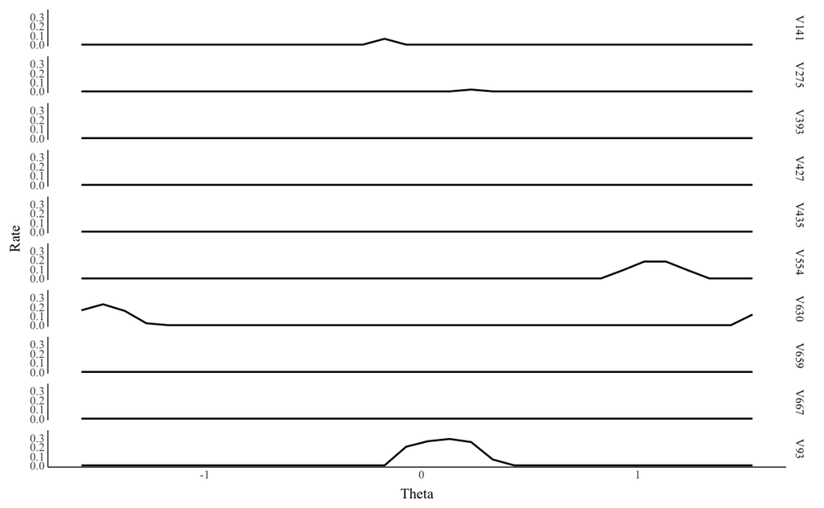

```r
df =
  y_V1 %>%
  as.data.frame() %>%
  mutate(Theta = all_theta) %>%
  gather(Cell, Rate, -Theta)
df %>%
  filter(Cell %in% sample(unique(Cell), 10)) %>%
  ggplot(aes(Theta, Rate)) +
  facet_grid(Cell~.) +
  geom_line(stat="summary", fun.data="mean_se")
```

# Comparing receptive fields before and after turnover

```r
y_V1_original =
  np$dot(y_LGN, w_LGN_to_V1_original) %>%
  apply(1, function(x) ifelse(x>.9*max(x), x, 0)) %>% t()
r = cor(y_V1, y_V1_original)
```

```
the standard deviation is zero
```

[output not shown]

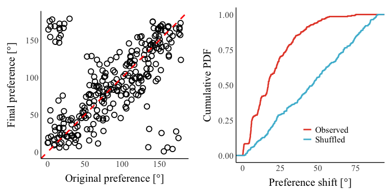

```r
a = y_V1_original %>% apply(2, function(x) rollmean(x, 170))
b = y_V1 %>% apply(2, function(x) rollmean(x, 170))
df_preference =
  data.frame(
    a = apply(y_V1_original, 2, which.max)/nrow(y_V1)*180-90,
    b = apply(y_V1, 2, which.max)/nrow(y_V1)*180-90,
    active = apply(y_V1, 2, function(x) max(x)>0)
  ) %>%
  filter(active) %>%
  select(a, b)
g1_preference =
  df_preference %>%
  mutate(Shift = {abs(a-b)} %>% ifelse(. > 90, 180-., .)) %>%
  ggplot(aes(a+90, b+90)) +
  geom_point(pch=21, fill=NA) +
  geom_abline(aes(slope=1, intercept=0), lty=2, color="red") +
  xlab("Original preference [°]") +
  ylab("Final preference [°]") +
  labs(color="Shift [°]") +
  coord_equal() +
  ylim(0, 180) +
  xlim(0, 180)
g2_preference =
  df_preference %>%
  mutate(b_shuffle = sample(b)) %>%
  mutate(
    Observed = abs(b - a),
    Shuffled = abs(b_shuffle - a)
    ) %>%
  select(Observed, Shuffled) %>%
  gather(Condition, Shift) %>%
  mutate(Shift = ifelse(Shift > 90, 180-Shift, Shift)) %>%
  ggplot(aes(Shift, color=Condition)) +
  geom_step(stat="ecdf") +
  xlab("Preference shift [°]") +
  ylab("Cumulative PDF") +
  theme(
    legend.title = element_blank(),
    legend.position = c(.6, .2),
    legend.background = element_rect(fill=NA)
    ) +
  scale_color_npg() +
  guides(color=guide_legend(keywidth=.5, keyheight=.5))
plot_grid(g1_preference, g2_preference)
```

# Visualizing receptive fields

[output not shown]

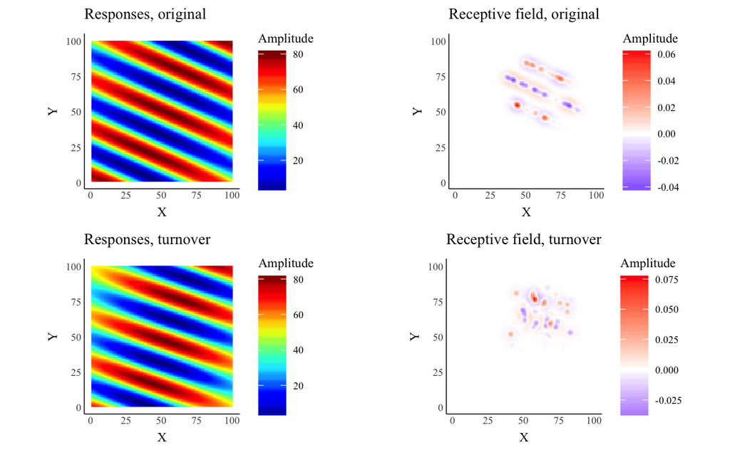

```r
V1_cell = sample(which(colSums(y_V1)>0), 1)
x = sapply(1:nrow(stimuli), function(i) {
  stimuli[i,] * y_V1[i, V1_cell]
}) %>%
  t()
g1 =
  colSums(x) %>%
  matrix(100, 100) %>%
  melt() %>%
  ggplot(aes(Var1, Var2, fill=value)) +
  geom_raster() +
  scale_fill_gradientn(colors=jet.col()) +
  coord_equal() +
  ggtitle("Responses, turnover") +
  labs(x="X", y="Y", fill="Amplitude")
inputs = which(w_LGN_to_V1[,V1_cell] > 0)
photoreceptor_fields = w_photoreceptors_to_LGN[,inputs]
LGN_weights = w_LGN_to_V1[inputs, V1_cell]
for (i in seq_along(LGN_weights)) {
  photoreceptor_fields[, i] = photoreceptor_fields[, i] * LGN_weights[i]
}
g2 =
  photoreceptor_fields %>%
  rowSums() %>%
  matrix(100, 100) %>%
  melt() %>%
  ggplot(aes(Var1, Var2, fill=value)) +
  geom_raster() +
  scale_fill_gradient2(low="blue", midpoint=0, mid="white", high="red") +
  coord_equal() +
  ggtitle("Receptive field, turnover") +
  labs(x="X", y="Y", fill="Amplitude")
x = sapply(1:nrow(stimuli), function(i) {
  stimuli[i,] * y_V1_original[i, V1_cell]
}) %>%
  t()
g3 =
  colSums(x) %>%
  matrix(100, 100) %>%
  melt() %>%
  ggplot(aes(Var1, Var2, fill=value)) +
  geom_raster() +
  scale_fill_gradientn(colors=jet.col()) +
  coord_equal() +
  ggtitle("Responses, original") +
  labs(x="X", y="Y", fill="Amplitude")
inputs = which(w_LGN_to_V1_original[,V1_cell] > 0)
photoreceptor_fields = w_photoreceptors_to_LGN[,inputs]
LGN_weights = w_LGN_to_V1_original[inputs, V1_cell]
for (i in seq_along(LGN_weights)) {
  photoreceptor_fields[, i] = photoreceptor_fields[, i] * LGN_weights[i]
}
g4 =
  photoreceptor_fields %>%
  rowSums() %>%
  matrix(100, 100) %>%
  melt() %>%
  ggplot(aes(Var1, Var2, fill=value)) +
  geom_raster() +
  scale_fill_gradient2(low="blue", midpoint=0, mid="white", high="red") +
  coord_equal() +
  ggtitle("Receptive field, original") +
  labs(x="X", y="Y", fill="Amplitude")
plot_grid(g3, g4, g1, g2)
```